# Simulation study with varied sparsity level

Se Yoon Lee, Peng Zhao, Debdeep Pati, and Bani Mallick

*NOTE:* Objective of this code is to reproduce the Figure 7 (The Horseshoe) and Figure 8 (GLT prior) in the main paper. As shown in the main paper, reviewers will see the collapsing behavior of the Horseshoe in a moderately sparse regime where the GLT prior still can detect signals.

To recall, we consider a linear regression
$$\textbf{y}=\textbf{X} \beta_0 +
\sigma_0\epsilon, \quad \epsilon \sim
\mathcal{N}_{n}(\textbf{0},\textbf{I}_n), \quad \textbf{X} \in
\mathbb{R}^{n \times p}$$
where $n = 100$ and $p = 500$. The true data generating parameter vector $\beta_0 \in \mathbb{R}^{p}$ is composed of signal and noise parts: the first $q$ coefficients are ones and the rest of the thems are zeros. The sparsity level is then defined by the ratio $q/p$. In the simulation setting, $q/p = 0.004$, $0.01$, $0.016$, and $0.026$, are considered as the sparsity levels. See the Section 7 of the main paper for a detail.

Install library packages

```r
library("ggplot2")
library("horseshoe") # by Stephanie van der Pas
library("MASS")
library("gridExtra")
library("compiler")
```

Bring external functions (To implement reviewers should set directory by setwd().)

Simulation environment (We used (nmc,burn,thin) = (10000,10000,100))

```r
nmc = 10000 # Number of mcmc samples after burning
burn = 10000 # Number of burned samples
thin = 100   # Thin number
```

# Figure 7 in the main paper (the Horseshoe prior)

To implement the horseshoe prior, use $\textsf{horseshoe_van_der_pas}(y = \textbf{y}, X = \textbf{X}, \text{method.tau = "halfCauchy", method.sigma = "Jeffreys", burn = burn, nmc = nmc, thin = thin})$ where $\textbf{y} \in \mathbb{R}^{n}$ is the response vector and $\textbf{X} \in \mathbb{R}^{n \times p}$ is the design matrix.

[output not shown]

[output not shown]

[output not shown]

[output not shown]

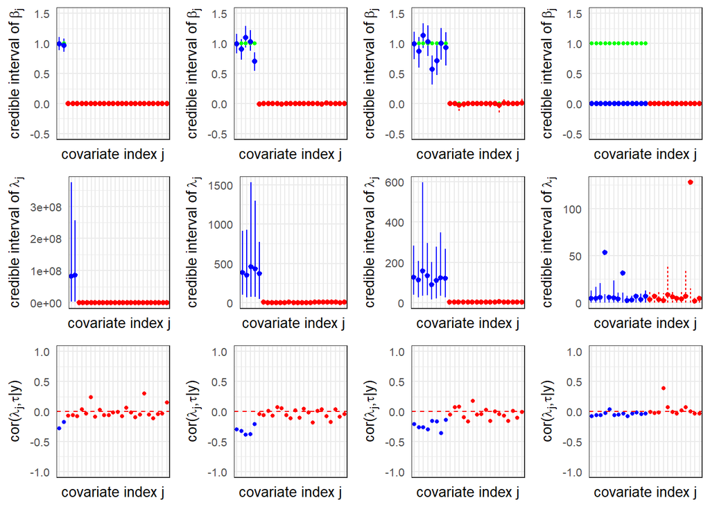

The posterior means of global-scale parameter $\tau$ (sparsity levels increase from the left to the right.)

```
## [1] 1.412900e-06 5.346205e-02 1.283351e-01 6.581918e-15
```

# Figure 8 in the main paper (GLT prior)

To implement the GLT prior, use $\textsf{GLT_prior}(y = \textbf{y}, X = \textbf{X}, \text{BCM_sampling = TRUE, burn = burn, nmc = nmc, thin = thin})$ where $\textbf{y} \in \mathbb{R}^{n}$ is the response vector and $\textbf{X} \in \mathbb{R}^{n \times p}$ is the design matrix.

[output not shown]

[output not shown]

[output not shown]

[output not shown]

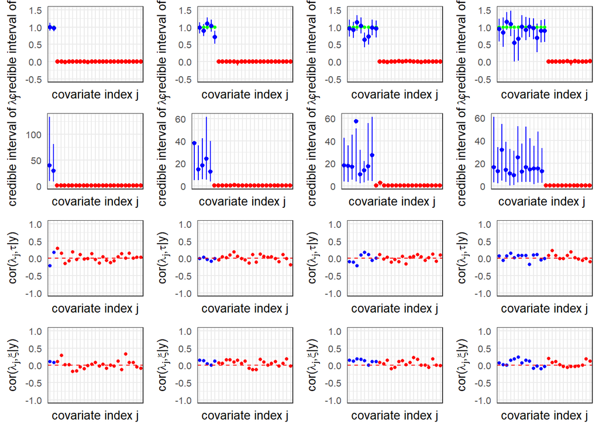

The posterior means of global-scale parameter $\tau$ and the shape parameter $\xi$ (sparsity levels increase from the left to the right)

```
## [1] 0.003907018 0.004211102 0.004436980 0.004694242
```

```
## [1] 2.009889 2.134902 2.235083 2.347505
```

The posterior distribution of the shape parameter $\xi$ (sparsity levels increase from the left to the right)

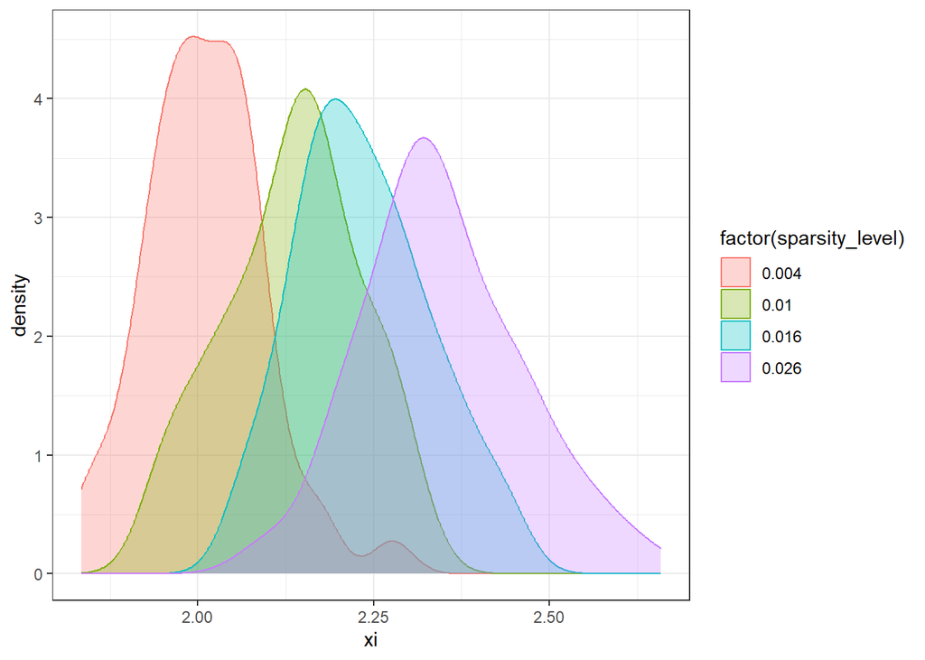